# HW5

Adam Ross

2025-04-15

1. Load house_prices.rda in R…

```r
# Load libraries
library(ggplot2)
library(tidyr)
library(dplyr)
library(lubridate)
# Load data
load("I:/.shortcut-targets-by-id/1ehWwunuAo7CE1Vk2JYkUnQMmxh5pph3C/DATA/house_prices.rda")
```

and perform the followings:

(a.) Use facet_wrap to draw line plots to represent the trend for house_price_index over years for each state. Please have three ticks on the x axis which are for years 1980, 2000, and 2020. Since you have limited space your labels can be ’80, ’00, and ’20 for these ticks.

```r
# (1a) Create line plots using facet_wrap
p1 <- ggplot(house_prices, aes(x = date, y = house_price_index)) +
  geom_line() +
  facet_wrap(~state) +
  scale_x_continuous(breaks = ymd(c("1980-01-01", "2000-01-01", "2020-01-01")), labels = c("80", "00", "20"))
  labs(title = "House Price Index Trend by State",
       x = "Year",
       y = "House Price Index")
```

```
## $x
## [1] "Year"
##
## $y
## [1] "House Price Index"
##
## $title
## [1] "House Price Index Trend by State"
##
## attr(,"class")
## [1] "labels"
```

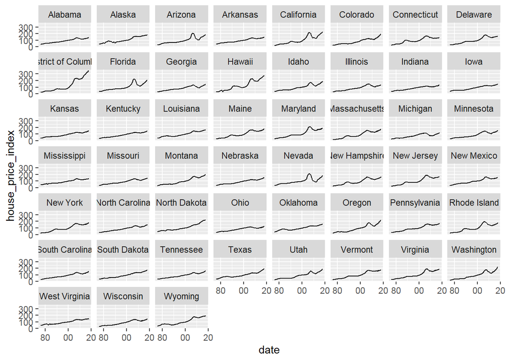

```r
print(p1)
```

(b.) Use gather() function from tidyr to reshape your data in a way that it will have measure and value columns for house_price_index and unemploy_perc, respectively, in two columns. You should leave out remaining attributes by using ”-” in front them inside the function. Then, direct the output to a new data frame called house_reshaped Please refer to examples we did in class.

```r
# (1b) Use gather() to reshape data
house_prices%>%gather("measure", "value", -state, -house_price_perc, -date)->house_reshaped

head(house_reshaped)
```

```
## # A tibble: 6 × 5
##   date       state   house_price_perc measure       value
##   <date>     <chr>              <dbl> <chr>         <dbl>
## 1 1976-01-01 Alabama           0.0404 unemploy_perc   6.7
## 2 1976-02-01 Alabama           0.0518 unemploy_perc   6.7
## 3 1976-03-01 Alabama           0.0593 unemploy_perc   6.6
## 4 1976-04-01 Alabama           0.0596 unemploy_perc   6.5
## 5 1976-05-01 Alabama           0.0557 unemploy_perc   6.4
## 6 1976-06-01 Alabama           0.0536 unemploy_perc   6.5
```

(c.) Use house_reshaped to replicate the graph in 1a with two lines where each represents house_price_index and unemploy_perc over the years for each state. Once you have the chart, please comment on it as to whether it’s a good graph to present those two pieces of information.

```r
# (1c) Use house_reshaped to replicate the graph in 1a with two lines
p2 <- ggplot(house_reshaped, aes(x = date, y = value, color=measure)) +
  geom_line() +
  facet_wrap(~state) +
  scale_x_continuous(breaks = ymd(c("1980-01-01", "2000-01-01", "2020-01-01")), labels = c("80", "00", "20"))
  labs(title = "House Price Index Trend by State",
       x = "Year",
       y = "House Price Index")
```

```
## $x
## [1] "Year"
##
## $y
## [1] "House Price Index"
##
## $title
## [1] "House Price Index Trend by State"
##
## attr(,"class")
## [1] "labels"
```

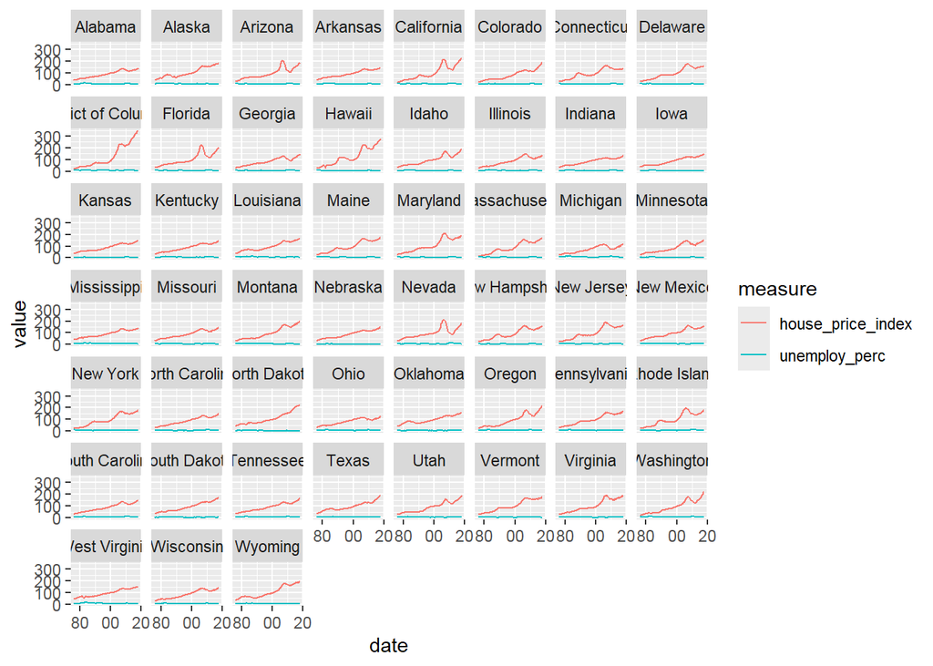

```r
print(p2)
```

These charts are not a good way to visualize these two data sets because the scale is so different between house_price_idex and unemploy_perc.

(d.) When you achieve the goals above, please create a R markdown file and create an HTML page which has your codes and charts including your comments.